# Simplified_biclust_walkthrough

2023-07-23

## Simplified biclust demo

The idea of this script is to walk through one iteration of our simplified version of biclust and find out either why the concept is flawed or if we are missing something that should be obvious.

The main idea is to consider biclust as a modular clustering algorithm that in general should be able to take in any kind of linear model-like method and use it for clustering. The core idea is that we have something that builds a linearisch model that we can use to derive r2 for cells in the cluster, and predicted r2 values for cells in other clusters (those that were not used for fitting that particular models), so we can use these r2/predicted r2 to reassign cells to clusters and re-fit models.

For this ultra-simple example, we will try this concept using the simplest thinkable method: a linear model of one dependent and one independent variable.

## Simulating some data

First, we build some gene expression for some regulator genes.

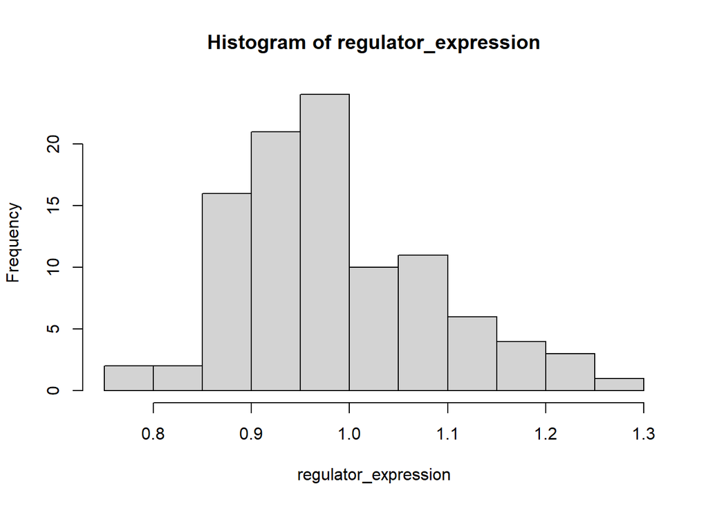

```r
num_cells <- 100
regulator_expression <- rnorm(num_cells, mean = 1, sd = 0.1)
hist(regulator_expression)
```

Now using these regulator gene expressions we will build some target gene expressions. We want the target gene expressions to be clearly clustered for this example. This will correspond to them being built from different regulatory models. So, first we define how many clusters we want, and define our regulatory model for each cell cluster.

```r
n_cell_clusters    <- 2
# Sample intercepts
intercepts <- rnorm(n_cell_clusters, mean = 10, sd = 5)
# Sample slopes
betas      <- rnorm(n_cell_clusters, mean = 1,  sd = 0.5)
# Assign half of the cells to be in either cluster
true_cell_clust <- c(rep(1,num_cells/2), rep(2,num_cells/2))
```

Next we use these parameters to generate target gene expression.

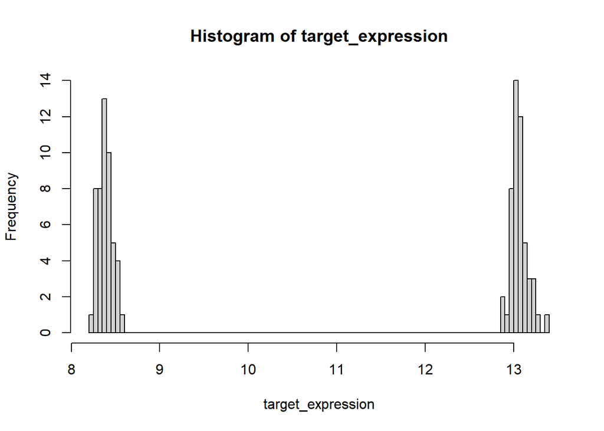

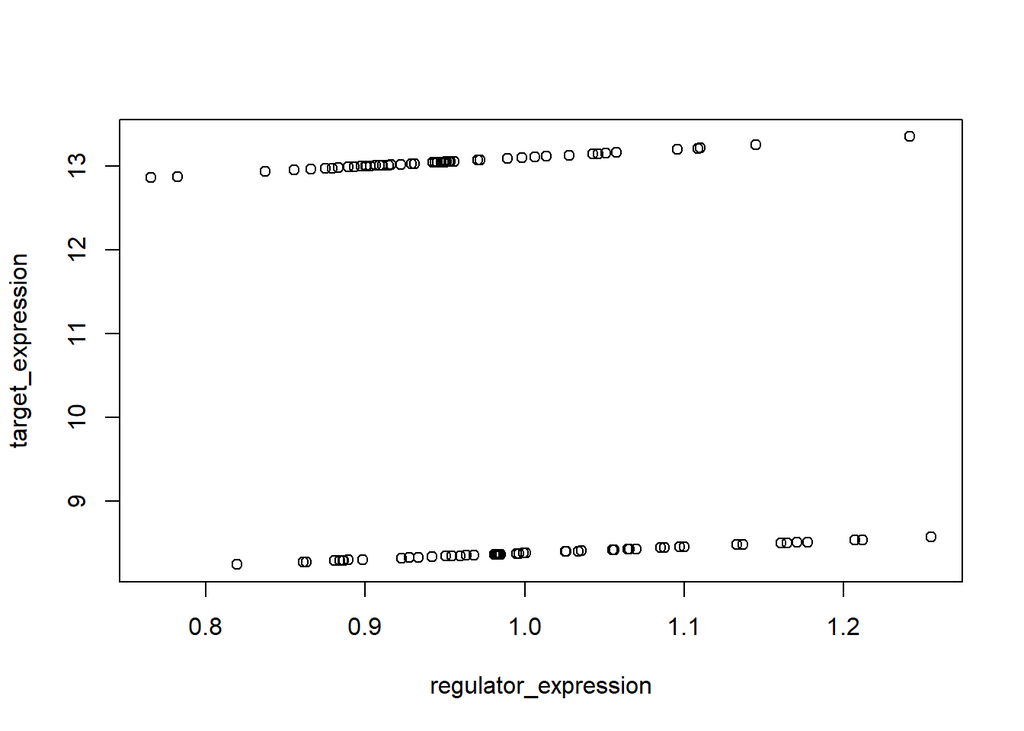

```r
# Build cell expression from linear model
cell_cluster_expression <- sapply(1:n_cell_clusters, function(cellCluster) c(intercepts[cellCluster], betas[cellCluster]) %*%
                                        t(cbind(rep(1, num_cells/2), regulator_expression[which(true_cell_clust == cellCluster)]))
      )

target_expression <- c(cell_cluster_expression[,1], cell_cluster_expression[,2])
dat <- cbind(target_expression, regulator_expression)

hist(target_expression, breaks = 100)
plot(dat[,c(2,1)])
```

The end goal of the real biclust is that it can use another clustering method to find initial cluster labels, and then hopefully it could improve upon this using the additional information from scregclust

For this simple example, our idea is to put some observations into the wrong cluster, and see if the biclust-algorithm can put them back to the true cluster. We set up cluster labels with mostly true labels, but a proportion of the labels permuted.

```r
disturbed_initial_cell_clust <- true_cell_clust
disturbed_fraction <- 0.20
for(i_cluster in 1:n_cell_clusters){
  indexes_of_cluster <- which(true_cell_clust == i_cluster)
  some_of_those_indexes <- sample(indexes_of_cluster, size=as.integer(length(indexes_of_cluster)*disturbed_fraction), replace = F)
  disturbed_initial_cell_clust[some_of_those_indexes] <-
    sample(c(1:n_cell_clusters)[-i_cluster],
           size=length(some_of_those_indexes), replace=T)
}


cell_cluster_history <- cbind(true_cell_clust, disturbed_initial_cell_clust)
colnames(cell_cluster_history) <- c("True allocation", "Disturbed allocation")
```

## Biclust, first iteration

Now it’s time to actually do something resembling biclust.

The real thing would obviously work for many iterations, but for now lets just walk through one iteration.

First we set up and preallocate some variables that we’ll use later.

```r
i_main <- 1  # Main iteration variable, just set it to one for now.
max_iter <- 1  # This one would usually cap number of iterations, set to 1 for now


# Find initial cluster labels
initial_clustering <- disturbed_initial_cell_clust
n_target_gene_clusters <- 1  # We are not clustering target genes for now and we only have one target gene


# Set up some variables
n_cell_clusters = length(unique(initial_clustering))
n_target_genes = 1
n_regulator_genes = 1


# Set up cluster history
initial_column_padding <- ncol(as.matrix(initial_clustering)) + 1  # +1 Because we have an index column that is not an index column it's an ID column
cell_cluster_history <- data.frame(matrix(NA, nrow = nrow(as.matrix(initial_clustering)), ncol = max_iter + initial_column_padding))
colnames(cell_cluster_history) <- c("Cell ID", 'Initial clustering', paste0("Iteration ", 1:max_iter))
cell_cluster_history[, 'Cell ID'] <-1:length(initial_clustering)  # Set cell names
cell_cluster_history[, 'Initial clustering'] <- initial_clustering


# Pre-allocate all r2 matrices for later analysis if feasible
r2_all <- vector("list", length = max_iter)

# Set flag for breaking out of the loop.
stop_iterating_flag = T

# Set the current cell clustering
current_cell_cluster_allocation <- initial_clustering
```

First step is to, for each cell cluster separately, fit a standard linear model.

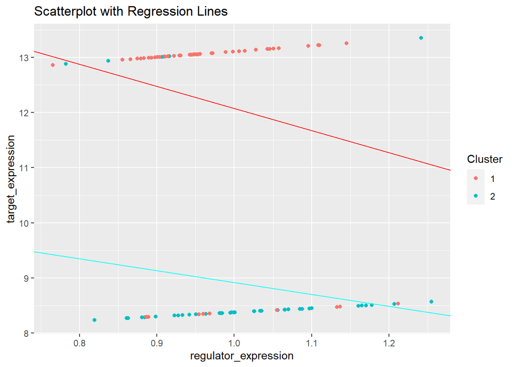

```r
 # Fit model to each cell cluster
  models <- vector("list", length = n_cell_clusters)
  dat <- cbind(dat, NA)  # Add columns so we can have colors for clusters in the plot
  colnames(dat)[3] <- 'cluster'  # Name that column
  for(cell_cluster in 1:n_cell_clusters){
    current_rows <- which(current_cell_cluster_allocation == cell_cluster)
    dat[current_rows, 'cluster'] <- cell_cluster  # Again, so we can plot the colors for each cluster
    models[[cell_cluster]] <- lm(dat[current_rows,'target_expression'] ~ dat[current_rows,'regulator_expression'])
  }

p <- ggplot(as.data.frame(dat[,]), aes(x = regulator_expression, y = target_expression, color=factor(cluster))) +
  geom_point() +
  geom_abline(intercept = coef(models[[1]])[1], slope = coef(models[[1]])[2], color = "red") +
  geom_abline(intercept = coef(models[[2]])[1], slope = coef(models[[2]])[2], color = "cyan") +
  labs(title = "Scatterplot with Regression Lines")
p + labs(color = "Cluster")
# Reset changes used for this plot
dat <- dat[,1:2]
```

Now that we have fitted some models, it’s time to re-allocate cells to appropriate clusters. To do this, we need to calculate the r2/predicted r2 for each cell, for each cell cluster.

```
## [1] "1 1"
```

```
## [1] "1 2"
```

```
## [1] "2 1"
```

```
## [1] "2 2"
```

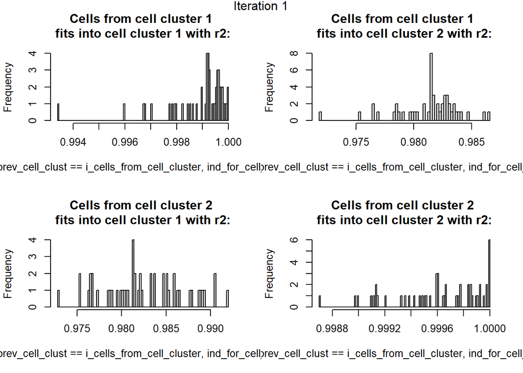

```r
# For all cells, calculate the predicted r2 for all cell clusters.
  r2 <- matrix(0, nrow = nrow(dat), ncol = n_cell_clusters)

  # First calculate the mean target gene expression in these clusters
  # also the total sum of squares in that cluster
  target_gene_means <- vector('numeric', length = n_cell_clusters )
  SS_tot <- vector('numeric', length = n_cell_clusters )
  for(cell_cluster in 1:n_cell_clusters){
    target_gene_means[cell_cluster] <- mean(dat[which(current_cell_cluster_allocation == cell_cluster),1])
    SS_tot[cell_cluster]  <- sum((dat[,1] - target_gene_means[cell_cluster])^2)
  }

  # Now to actually caltulate predicted or 'predicted' r2
  for(cell in 1:nrow(dat)){
    for(cell_cluster in 1:n_cell_clusters){
      # Bug fix hack: remove NA coefficients
      if(any(is.na(models[[cell_cluster]]$coefficients))){
        NA_coeffs <-  unname(which(is.na(models[[cell_cluster]]$coefficients)))
        S_ERR <- (dat[cell,1] - as.vector(c(1,dat[cell,c(-1, -NA_coeffs)])) %*% models[[cell_cluster]]$coefficients[-NA_coeffs])^2
      }
      S_ERR <- (dat[cell,1] - as.vector(c(1,dat[cell,-1])) %*% models[[cell_cluster]]$coefficients)^2
      r2[cell,cell_cluster] <- 1-(S_ERR/SS_tot[[cell_cluster]])
    }
  }

  r2_all[[i_main]] <- r2

  r2plot(iteration = i_main,
       r2 = r2,
       prev_cell_clust = true_cell_clust)
```

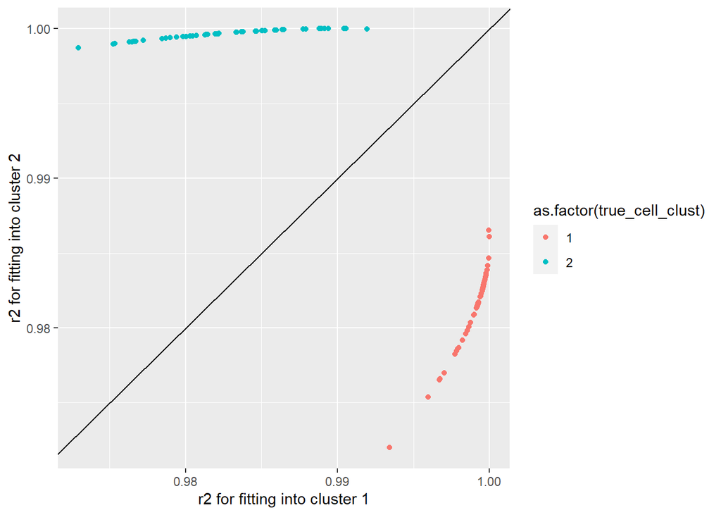

```r
  ggplot(data = as.tibble(cbind(r2, true_cell_clust)),
       aes(x = V1, y = V2, color = as.factor(true_cell_clust))
      ) +
  geom_point() +
    geom_abline(intercept = 0, slope = 1)+
    labs(x = "r2 for fitting into cluster 1", y = "r2 for fitting into cluster 2")
```

```r
  # Update cluster allocations
  updated_cell_clust <-  sapply(1:nrow(r2), function(row) which.min(r2[row,]))


  # Update data in cell_cluster_history
  cell_cluster_history[, i_main + initial_column_padding] <- updated_cell_clust

  RI(true_cell_clust,updated_cell_clust)
```

```
## [1] 1
```

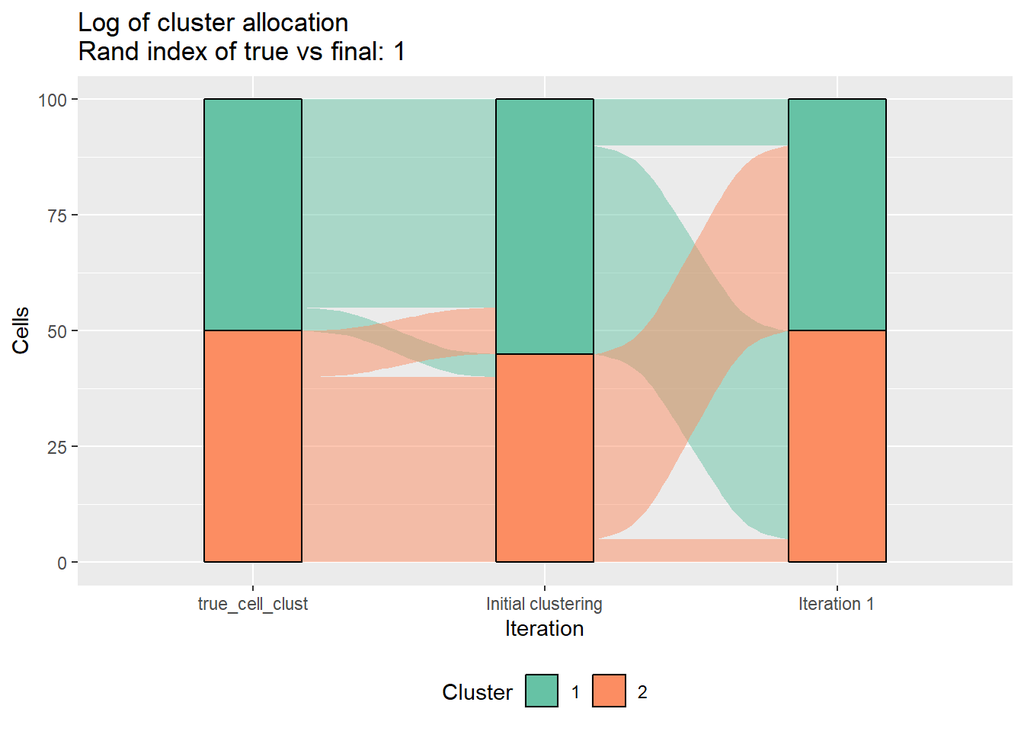

```r
cell_cluster_history <-cbind('Cell ID' = cell_cluster_history[,1],
                             true_cell_clust,
                             cell_cluster_history[,c(2,3)])

plot_cluster_history(cell_cluster_history = cell_cluster_history)
```